# Bitcoin Analysis

Alexander J. McNeil and Martin Bladt

2022-05-07

## The Bitcoin Log-Return Data

We first load the data and calculate log-returns.

```r
data(bitcoin)
X <- (diff(log(bitcoin))[-1]) * 100 # log-returns (as percentages)
length(X)
```

```
#> [1] 1043
```

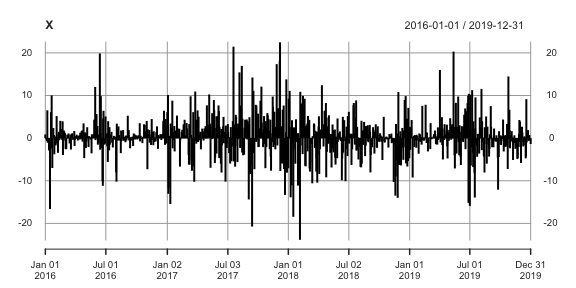

```r
plot(X, type = "h")
```

## Copula Processes

### ARMA Copulas

We start with the fulcrum profile-likelihood plot which indicates that a value $\delta = 0.45$ is about right.

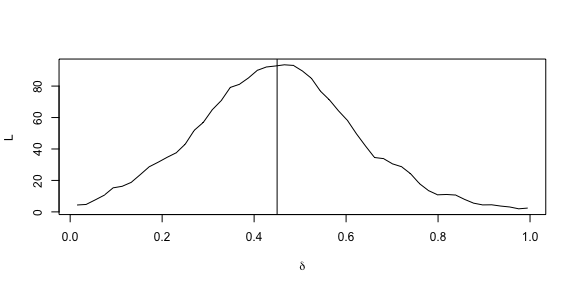

```r
U <- strank(X)

copmod_Gauss <- armacopula(pars = list(ar = 0.95, ma = -0.85))
pts <- seq(from=0.01, to=0.99, length=51) + 0.005
profilefulcrum(U, copmod_Gauss, locations = pts)
abline(v = 0.45)
```

Our baseline model is a model with ARMA(1,1) copula and v-transform with fulcrum at $\delta=0.45$.

```r
mod_Gauss <- vtscopula(copmod_Gauss, Vlinear(0.45))
fit_Gauss <- fit(mod_Gauss, U, tsoptions = tsoptions)
fit_Gauss
```

```
#> object class: vtscopula
#> ____________
#> Base copula:
#> object class: armacopula
#> name: ARMA(1,1)
#> parameters:
#>        ar1        ma1
#>  0.9631285 -0.8424401
#> ____________
#> V-transform:
#> name: Vlinear
#> parameters:
#> delta
#>  0.45
#> _____________________
#> Summary of estimates:
#>         ar.ar1      ma.ma1
#> par 0.96312845 -0.84244010
#> se  0.01146705  0.02698389
#> convergence status: 0, log-likelihood: 91.87754
```

### D-Vine Copula (second kind)

```r
copmod_Frank <- dvinecopula2(family = "frank",
                             pars = list(ar = 0.95, ma = -0.85),
                             maxlag = 30)
mod_Frank <- vtscopula(copmod_Frank, Vlinear(0.45))
fit_Frank <- fit(mod_Frank, U, tsoptions = tsoptions)

AIC(fit_Gauss, fit_Frank)
```

```
#>           df       AIC
#> fit_Gauss  2 -179.7551
#> fit_Frank  2 -186.4793
```

We provide plots for the model with Frank copula to show aspects of the fit.

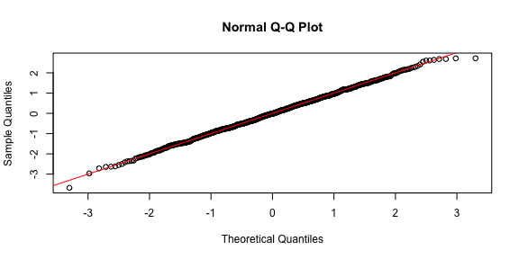

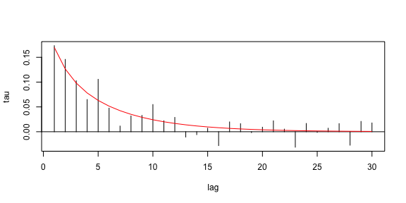

```r
plot(fit_Frank, plottype = "residual")
plot(fit_Frank, plottype = "kendall")
```

## Marginal Models

We fit 6 marginal distributions (3 symmetric and 3 skewed) of which the double Weibull gives the lowest AIC value.

```r
marg_st <- fit(margin("st"), X)
marg_sst <- fit(margin("sst"), X)
marg_lp <- fit(margin("laplace",
                      pars = c(mu = 0.2, scale = 2.7)), X)
marg_slp <- fit(margin("slaplace",
                pars = c(mu = 0.2, scale = 2.7, gamma = 0.9)), X)
marg_dw <- fit(margin("doubleweibull",
                      pars = c(mu = 0.2, shape = 0.8, scale = 2.7)), X)
marg_sdw <- fit(margin("sdoubleweibull",
                pars = c(mu = 0.2, shape = 0.8, scale = 2.7, gamma = 0.9)), X)
AIC(marg_st, marg_sst, marg_slp, marg_lp, marg_dw, marg_sdw)
```

```
#>          df      AIC
#> marg_st   3 5816.288
#> marg_sst  4 5818.249
#> marg_slp  3 5801.355
#> marg_lp   2 5799.447
#> marg_dw   3 5749.362
#> marg_sdw  4 5751.137
```

## Full Models

### D-Vine Copula

We fit a full model combining the double Weibull margin with the VT-d-vine model of the second kind.

```r
fullmod <- tscm(fit_Frank, margin = marg_dw)
fullmod <- fit(fullmod, as.numeric(X),
               method = "full", tsoptions = tsoptions)
fullmod
```

```
#> object class: tscmfit
#> _______
#> MARGIN:
#> name: doubleweibull
#> parameters:
#>        mu     shape     scale
#> 0.1916831 0.8440735 2.6642372
#> _______
#> COPULA:
#> object class: vtscopula
#> ____________
#> Base copula:
#> object class: dvinecopula2
#> name: type2-d-vine
#> copula family: frank
#> KPACF: kpacf_arma with max lag 30
#> parameters:
#>         ar         ma
#>  0.9597057 -0.8344572
#> ____________
#> V-transform:
#> name: Vlinear
#> parameters:
#> delta
#>  0.45
#> _________________________
#> summary of all estimates:
#>             ar          ma    margin.mu margin.shape margin.scale
#> par 0.95970567 -0.83445716 0.1916831037   0.84407354    2.6642372
#> se  0.01385987  0.02878664 0.0006240695   0.03193025    0.2641212
#> convergence status: 10 , log-likelihood: -2776.903
```

```r
AIC(marg_dw, fullmod)
```

```
#>         df      AIC
#> marg_dw  3 5749.362
#> fullmod  5 5563.807
```

We show all the possible plots for the full model.

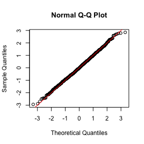

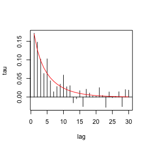

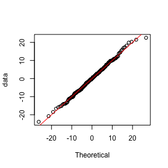

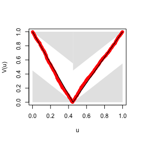

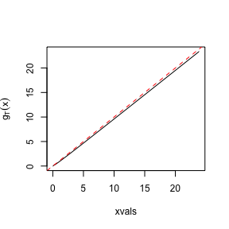

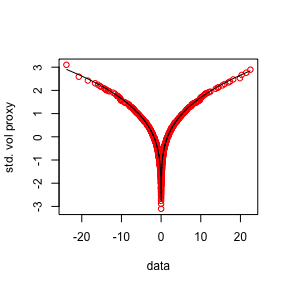

```r
plot(fullmod, plottype = "residual")
plot(fullmod, plottype = "kendall")
plot(fullmod, plottype = "margin")
plot(fullmod, plottype = "vtransform")
plot(fullmod, plottype = "volprofile")
plot(fullmod, plottype = "volproxy")
```

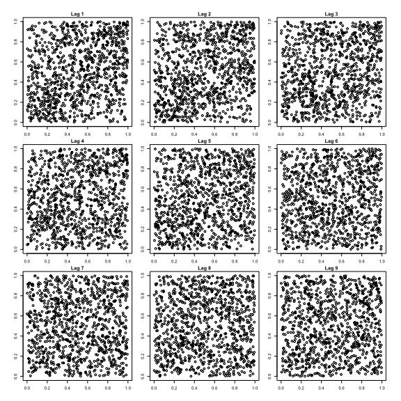

```r
plot(fullmod, plottype = "glag")
```